# SLR - Faculty Notebook (Day 1) [v5.0 - 161020]

|  | Faculty Notebook (Day 1) |
| --- | --- |

## Problem Statement

The New York City Controller's Office maintains a database of the salary and benefits paid to city employees since the financial year 2015. This is data representing the employee reimbursement report.

**Year:** Year of reimbursement

**Type_of_yr:** Financial (July through June) or Calendar (January through December)

**Emp_ID:** Each distinct number in the column represents one employee.

**Income:** Income paid to permanent or temporary City employees.

**Other_Income:** Various irregular payments made to City employees including premium pay, incentive pay, or other one-time payments.

**Overtime:** Amounts paid to employees for working in excess of 40 hours per week.

**Total_Income:** The sum of all income paid to employees.

**Health_Insurance:** Paid premiums to health insurance plans covering employees.

**Retirement:** City contributions to employee retirement plans.

**Other_Benefits:** Benefits paid on behalf of employees that are not included in the above categories.

**Total_Benefits:** The sum of all benefits paid to City employees.

**Total_Reimbursement:** The sum of all the income and benefits paid to City employees.

## Table of Content

1. **Import Libraries**
2. **Data Preparation**
   - 2.1 - **Understand the Data**
   - 2.2 - **Outlier Analysis and Treatment**
   - 2.3 - **Missing Value Analysis and Treatment**
   - 2.4 - **Scale the Data**
3. **What is Regression Analysis?**
4. **Bivariate Regression**
   - 4.1 - **Ordinary Least Square Method (OLS)**
   - 4.2 - **Measures of Variation**
     - 4.2.1 - **Sum of Squared Residuals (SSR)**
     - 4.2.2 - **Sum of Squared Error (SSE)**
     - 4.2.3 - **Sum of Squared Total (SST)**
     - 4.2.4 - **Coefficient of Determination (R-Squared)**
     - 4.2.5 - **Standard Error of Estimate (SEE)**
   - 4.3 - **Inferences about Slope and Intercept**
     - 4.3.1 - **Interpretation of Slope and Intercept**
     - 4.3.2 - **The t-test for Slope and Intercept**
     - 4.3.3 - **Confidence Interval for Slope and Intercept**
     - 4.3.4 - **ANOVA for SLR**
5. **Multiple Linear Regression (MLR)**
   - 5.1 - **Assumptions Before MLR Model**
     - 5.1.1 - **Assumption on Dependent Variable**
     - 5.1.2 - **No or Little Multicollinearity**
       - 5.1.2.1 - **Correlation Matrix**
       - 5.1.2.2 - **Variance Inflation Factor (VIF)**
   - 5.2 - **Build the MLR Model**
     - 5.2.1 - **MLR Full Model**
     - 5.2.2 - **MLR Model after Removing Insignificant Variables**
     - 5.2.3 - **MLR Model with Interaction Effect**
   - 5.3 - **Assumptions After MLR Model**
     - 5.3.1 - **Linear Relationship between Dependent and Independent Variable**
     - 5.3.2 - **Autocorrelation**
     - 5.3.3 - **Heteroskedasticity**
     - 5.3.4 - **Tests for Normality**
6. **Model Evaluation**
   - 6.1 - **R-Squared**
   - 6.2 - **Adjusted R-Squared**
   - 6.3 - **Overall F-Test & p-value of the Model**
7. **Model Performance**
   - 7.1 - **Mean Squared Error (MSE)**
   - 7.2 - **Root Mean Squared Error (RMSE)**
   - 7.3 - **Mean Absolute Error (MAE)**
   - 7.4 - **Mean Absolute Percentage Error (MAPE)**
8. **Compare Model Performances**

# 1. Import Libraries

**Let us import the required libraries.**

```python
# import 'Pandas'
import pandas as pd

# import 'Numpy'
import numpy as np

# import subpackage of Matplotlib
import matplotlib.pyplot as plt

# import 'Seaborn'
import seaborn as sns

# to suppress warnings
from warnings import filterwarnings
filterwarnings('ignore')

# display all columns of the dataframe
pd.options.display.max_columns = None

# display all rows of the dataframe
pd.options.display.max_rows = None

# to display the float values upto 6 decimal places
pd.options.display.float_format = '{:.6f}'.format

# import train-test split
from sklearn.model_selection import train_test_split

# import various functions from statsmodel to perform linear regression
import statsmodels
import statsmodels.api as sm
import statsmodels.stats.api as sms
from statsmodels.compat import lzip
from statsmodels.stats.outliers_influence import variance_inflation_factor
from statsmodels.graphics.gofplots import qqplot
from statsmodels.stats.anova import anova_lm
from statsmodels.formula.api import ols
from statsmodels.tools.eval_measures import rmse

# import various functions from scipy
from scipy import stats
from scipy.stats import shapiro

# 'metrics' from sklearn is used for evaluating the model performance
from sklearn.metrics import mean_absolute_error
from sklearn.metrics import mean_squared_error
```

# 2. Data Preparation

## 2.1 Understand the Data

#### Read the dataset and print the first five observations.

```python
# load the csv file
# store the data in 'df_reimb'
df_reimb = pd.read_csv('Emp_reimb.csv')

# display first five observations using head()
df_reimb.head()
```

|  | Year | Type_of_yr | Emp_ID | Income | Other_Income | Overtime | Total_Income | Health_Insurance | Retirement | Other_Benefits | Total_Benefits | Total_Reimbursement |
| --- | --- | --- | --- | --- | --- | --- | --- | --- | --- | --- | --- | --- |
| 0 | 2015 | Financial | 42865 | 92288.220000 | 267.450000 | 270.450000 | 92826.120000 | 12500.560000 | 20703.200000 | 7605.750000 | 40809.510000 | 133635.630000 |
| 1 | 2015 | Calendar | 28253 | 1466.380000 | 0.000000 | 350.230000 | 1816.610000 | 442.030000 | 3.000000 | 141.590000 | 586.620000 | 2403.230000 |
| 2 | 2018 | Financial | 30664 | 76536.950000 | 10855.940000 | 13586.720000 | 100979.610000 | 12464.610000 | 18636.190000 | 8011.410000 | 39112.210000 | 140091.820000 |
| 3 | 2018 | Financial | 19482 | 45659.880000 | 1625.370000 | 3.000000 | 47288.250000 | 0.000000 | 10084.200000 | 3936.630000 | 14020.830000 | 61309.080000 |
| 4 | 2017 | Financial | 7183 | 41832.000000 | 0.000000 | 6.000000 | 41838.000000 | 5908.520000 | 7621.600000 | 3254.500000 | 16784.620000 | 58622.620000 |

**Let us now see the number of variables and observations in the data.**

```python
# use 'shape' to check the dimension of data
df_reimb.shape
```

```
(49794, 12)
```

**Interpretation:** The data has 49794 observations and 12 variables.

**Get a concise summary of the DataFrame.**

```python
# use 'info()' to understand the dataset
df_reimb.info()
```

```
<class 'pandas.core.frame.DataFrame'>
RangeIndex: 49794 entries, 0 to 49793
Data columns (total 12 columns):
 #   Column               Non-Null Count  Dtype
---  ------               --------------  -----
 0   Year                 49794 non-null  int64
 1   Type_of_yr           49794 non-null  object
 2   Emp_ID               49794 non-null  int64
 3   Income               49794 non-null  float64
 4   Other_Income         49794 non-null  float64
 5   Overtime             49794 non-null  float64
 6   Total_Income         49794 non-null  float64
 7   Health_Insurance     49794 non-null  float64
 8   Retirement           49794 non-null  float64
 9   Other_Benefits       49794 non-null  float64
 10  Total_Benefits       49794 non-null  float64
 11  Total_Reimbursement  49794 non-null  float64
dtypes: float64(9), int64(2), object(1)
memory usage: 4.6+ MB
```

**Interpretation:** The variable `Type_of_yr` is categorical. All the other variables are numerical.

From the above output, we see that the data type of `Year` is 'int64'.

But according to the data definition, `Year` is categorical variable, which is wrongly interpreted as 'int64', so we will convert these variables data type to 'object'.

#### Change the data type as per the data definition.

```python
# convert numerical variables to categorical (object)
# use astype() to change the data type

# change the data type of 'Year'
df_reimb['Year'] = df_reimb['Year'].astype(object)
```

#### Recheck the data type after the conversion.

```python
# recheck the data types using 'dtypes'
df_reimb.dtypes
```

```
Year                    object
Type_of_yr              object
Emp_ID                   int64
Income                 float64
Other_Income           float64
Overtime               float64
Total_Income           float64
Health_Insurance       float64
Retirement             float64
Other_Benefits         float64
Total_Benefits         float64
Total_Reimbursement    float64
dtype: object
```

**Interpretation:** Now, all the variables have the correct data type.

## 2.3 Remove Insignificant Variables

The column `Emp_ID` contains the id of the employee, which is redundant for further analysis. Thus, we drop the column.

```python
# drop the column 'Emp_ID' using drop()
# 'axis = 1' drops the specified column
df_reimb = df_reimb.drop('Emp_ID',axis=1)
```

## 2.2 Outlier Analysis and Treatment

**Check the outliers in all the variables and treat them using appropriate techniques.**

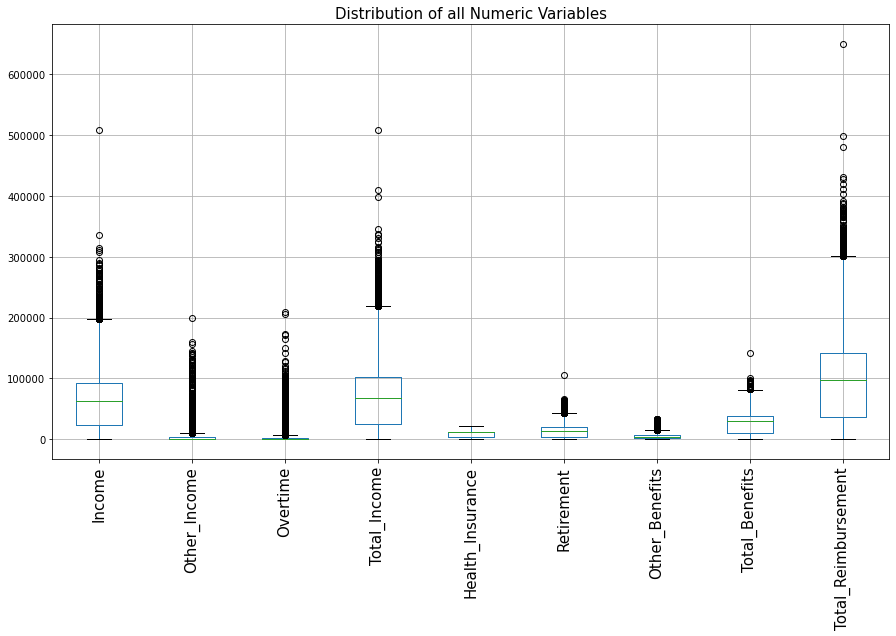

```python
# set the plot size using figure()
# pass width and height in inches to 'figsize'
plt.figure(figsize = (15,8))

# plot a boxplot to visualize the outliers in all the numeric variables
df_reimb.boxplot()

# set plot label
# set text size using 'fontsize'
plt.title('Distribution of all Numeric Variables', fontsize = 15)

# xticks() returns the x-axis ticks
# 'rotation = vertical' rotates the x-axis labels vertically
plt.xticks(rotation = 'vertical', fontsize = 15)

# display the plot
plt.show()
```

**Notice that the variables 'Income', 'Total_Income' and 'Total_Reimbursement' have a quite large range as compared to the other variables. Thus, it is difficult to see the outliers in such variables. So, we plot the boxplots of independent variables again by not considering the variables 'Income', 'Total_Income' and 'Total_Reimbursement'. The variable Health_Insurance has no outliers.**

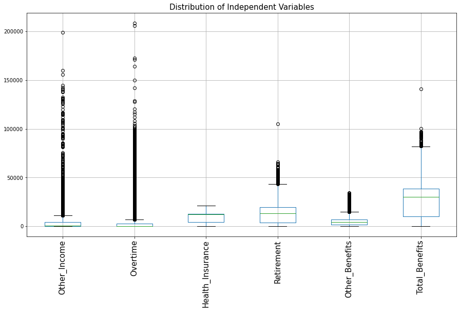

```python
# boxplot of independent variables

# set the plot size using figure()
# pass width and height in inches to 'figsize'
plt.figure(figsize = (15,8))

# plot boxplots of all the numeric variables except the variables 'Income', 'Total_Income' and 'Total_Reimbursement'
# use 'loc[]' to select the variables
df_reimb.loc[:,['Other_Income', 'Overtime', 'Health_Insurance', 'Retirement', 'Other_Benefits', 'Total_Benefits']].boxplot()

# set plot label
# set text size using 'fontsize'
plt.title('Distribution of Independent Variables', fontsize = 15)

# xticks() returns the x-axis ticks
# 'rotation = vertical' rotates the x-axis labels vertically
plt.xticks(rotation = 'vertical', fontsize = 15)

# display the plot
plt.show()
```

**Interpretation:** From the above plots, we notice that all the variables except 'Helath_Insurance' have points above the upper extreme or below the lower extreme - these points are outliers in the data. However, the exact location of these points is not precisely seen.

Let us use the IQR method to remove the outliers.

```python
# calculate the first quartile
Q1 = df_reimb.quantile(0.25)

# calculate the third quartile
Q3 = df_reimb.quantile(0.75)

# The Interquartile Range (IQR) is defined as the difference between the third and first quartile
# calculate IQR for each numeric variable
IQR = Q3 - Q1

# retrieve the dataframe without the outliers
# '~' returns the values that do not satisfy the given conditions
# i.e. it returns values between the range [Q1-1.5*IQR, Q3+1.5*IQR]
# '|' is used as 'OR' operator on multiple conditions
# 'any(axis=1)' checks the entire row for atleast one 'True' entry (those rows represents outliers in the data)
df_reimb = df_reimb[~((df_reimb < (Q1 - 1.5 * IQR)) | (df_reimb > (Q3 + 1.5 * IQR))).any(axis=1)]

# check the shape of the data
df_reimb.shape
```

```
(37601, 11)
```

**Interpretation:** A crude way to know whether the outliers have been removed or not is to check the dimensions of the data. From the above output, we can see that the dimensions are reduced that implies outliers are removed.

## 2.3 Missing Value Analysis and Treatment

**Check the presence of missing values in the data and treat them.**

```python
# sort the variables on the basis of total null values in the variable
# 'isnull().sum()' returns the number of missing values in each variable
# 'ascending = False' sorts values in the descending order
# the variable with highest number of missing values will appear first
Total = df_reimb.isnull().sum().sort_values(ascending=False)

# calculate percentage of missing values
# 'ascending = False' sorts values in the descending order
# the variable with highest percentage of missing values will appear first
Percent = (df_reimb.isnull().sum()*100/df_reimb.isnull().count()).sort_values(ascending=False)

# concat the 'Total' and 'Percent' columns using 'concat' function
# pass a list of column names in parameter 'keys'
# 'axis = 1' concats along the columns
missing_data = pd.concat([Total, Percent], axis=1, keys=['Total', 'Percentage of Missing Values'])
missing_data
```

|  | Total | Percentage of Missing Values |
| --- | --- | --- |
| Total_Reimbursement | 0 | 0.000000 |
| Total_Benefits | 0 | 0.000000 |
| Other_Benefits | 0 | 0.000000 |
| Retirement | 0 | 0.000000 |
| Health_Insurance | 0 | 0.000000 |
| Total_Income | 0 | 0.000000 |
| Overtime | 0 | 0.000000 |
| Other_Income | 0 | 0.000000 |
| Income | 0 | 0.000000 |
| Type_of_yr | 0 | 0.000000 |
| Year | 0 | 0.000000 |

**Interpretation:** There are no missing values in the data.

## 2.4 Scale the Data

```python
# check the head of the data
df_reimb.head()
```

|  | Year | Type_of_yr | Income | Other_Income | Overtime | Total_Income | Health_Insurance | Retirement | Other_Benefits | Total_Benefits | Total_Reimbursement |
| --- | --- | --- | --- | --- | --- | --- | --- | --- | --- | --- | --- |
| 0 | 2015 | Financial | 92288.220000 | 267.450000 | 270.450000 | 92826.120000 | 12500.560000 | 20703.200000 | 7605.750000 | 40809.510000 | 133635.630000 |
| 1 | 2015 | Calendar | 1466.380000 | 0.000000 | 350.230000 | 1816.610000 | 442.030000 | 3.000000 | 141.590000 | 586.620000 | 2403.230000 |
| 3 | 2018 | Financial | 45659.880000 | 1625.370000 | 3.000000 | 47288.250000 | 0.000000 | 10084.200000 | 3936.630000 | 14020.830000 | 61309.080000 |
| 4 | 2017 | Financial | 41832.000000 | 0.000000 | 6.000000 | 41838.000000 | 5908.520000 | 7621.600000 | 3254.500000 | 16784.620000 | 58622.620000 |
| 5 | 2017 | Calendar | 74132.000000 | 1443.420000 | 4.000000 | 75579.420000 | 12888.340000 | 14855.230000 | 6233.850000 | 33977.420000 | 109556.840000 |

```python
# scale the independent numeric and target variable
df_reimb.iloc[:, 2:11] = df_reimb.iloc[:, 2:11].apply(lambda rec: (rec - rec.mean()) / rec.std())

df_reimb.head()
```

|  | Year | Type_of_yr | Income | Other_Income | Overtime | Total_Income | Health_Insurance | Retirement | Other_Benefits | Total_Benefits | Total_Reimbursement |
| --- | --- | --- | --- | --- | --- | --- | --- | --- | --- | --- | --- |
| 0 | 2015 | Financial | 0.979272 | -0.476483 | -0.234449 | 0.921924 | 0.911621 | 1.173963 | 1.141794 | 1.156388 | 0.996728 |
| 1 | 2015 | Calendar | -1.259481 | -0.588280 | -0.175594 | -1.270526 | -1.504303 | -1.186975 | -1.269380 | -1.374560 | -1.312351 |
| 3 | 2018 | Financial | -0.170114 | 0.091140 | -0.431752 | -0.175099 | -1.592864 | -0.037175 | -0.043455 | -0.529238 | -0.275882 |
| 4 | 2017 | Financial | -0.264471 | -0.588280 | -0.429539 | -0.306397 | -0.409093 | -0.318044 | -0.263806 | -0.355332 | -0.323152 |
| 5 | 2017 | Calendar | 0.531722 | 0.015083 | -0.431014 | 0.506445 | 0.989313 | 0.506980 | 0.698624 | 0.726492 | 0.573053 |

# 3. What is Regression Analysis?

#### Dependent variable (y): It is the variable that we predict. It is also known as 'Target' or 'Response' variable. For regression, the dependent variable should be numeric.

#### Independent variable (X): It is the variable used in predicting the values of a target variable. There can be one or more independent variables in a dataset. It is also known as 'predictors' or 'features'. These variables can be numerical as well as categorical.

Regression analysis is used to understand the effect of a set of independent variables on the dependent variable. The variables that affect the dependent variable the most can also be identified. Linear regression is one of the methods in regression analysis, which fits the line to predict the values of the dependent variable.

# 4. Bivariate Regression

It determines the linear relationship between the dependent (y) and a independent (X) variable. It is also known as, `Simple Linear Regression (SLR)`. The mathematical equation is given as:

**y = β<sub>0</sub> + β<sub>1</sub>.x + ε**

where,

y = Dependent variable  
x = Independent variable  
β<sub>0</sub> = Y-intercept (value of y when x = 0)  
β<sub>1</sub> = Beta coefficient of x  
ε = Random error component

**For bivariate regression, consider 'Total_Reimbursement' as target variable and 'Total_Benefits' as an independent variable from 'df_reimb'.**

The test hypothesis for SLR is given as:

**H<sub>o</sub>: Slope (beta coefficient of x) is equal to zero**

**H<sub>1</sub>: Slope (beta coefficient of x) is not equal to zero**

## 4.1 Ordinary Least Square Method (OLS)

The ordinary least square method aims to minimize the sum of the squared difference between the actual and the predicted values. Squaring ensures that each term is positive. It penalizes the model for the negative error terms. This approach calculates the β<sub>0</sub> and β<sub>1</sub> values that minimize the sum of squared differences along the line of prediction.

#### Split the data into training and test sets

```python
# split the independent and target variable into train subset and test subset
# set 'random_state' to generate the same dataset each time you run the code
# 'test_size' returns the proportion of data to be included in the testing set
X_train_slr, X_test_slr, y_train_slr, y_test_slr = train_test_split(df_reimb['Total_Benefits'], df_reimb['Total_Reimbursement'],
                                                    random_state=1, test_size = 0.3)

# check the dimensions of the train & test subset using 'shape'
# print dimension of train set
print('X_train_slr', X_train_slr.shape)
print('y_train_slr', y_train_slr.shape)

# print dimension of test set
print('X_test_slr', X_test_slr.shape)
print('y_test_slr', y_test_slr.shape)
```

```
X_train_slr (26320,)
y_train_slr (26320,)
X_test_slr (11281,)
y_test_slr (11281,)
```

**Build the simple linear regression model using the OLS method.**

```python
# convert the X_train to DataFrame
X_train_slr = pd.DataFrame(X_train_slr)

# insert a column of intercept to 'X_train_slr'
# create an array of ones with length equal to the total number of observations
c = np.ones(X_train_slr.shape[0])

# A design matrix is a matrix of observations of independent variables whose first column is of ones
# If there are 'm' observations and 'n' variables, then the dimension of a design matrix is m * (n+1)

# add the intercept
# pass location index of intercept to the parameter 'loc'
# pass column name to the parameter 'column'
# pass the column value to the parameter 'value'
X_train_slr.insert(loc = 0, column = 'intercept', value = c)

# display the first five rows of design matrix
X_train_slr.head()
```

|  | intercept | Total_Benefits |
| --- | --- | --- |
| 32437 | 1.000000 | -0.924063 |
| 27382 | 1.000000 | 0.897157 |
| 26627 | 1.000000 | -1.355352 |
| 24073 | 1.000000 | 0.797800 |
| 49495 | 1.000000 | 1.041847 |

```python
# building a model on the train dataset with an intercept
# fit() is used to fit the OLS model
SLR_model = sm.OLS(y_train_slr, X_train_slr).fit()

# print the summary output
print(SLR_model.summary())
```

```
                             OLS Regression Results
===============================================================================
Dep. Variable:     Total_Reimbursement   R-squared:                       0.949
Model:                             OLS   Adj. R-squared:                  0.949
Method:                  Least Squares   F-statistic:                 4.848e+05
Date:                 Fri, 16 Oct 2020   Prob (F-statistic):               0.00
Time:                         15:58:57   Log-Likelihood:                 1661.7
No. Observations:                26320   AIC:                            -3319.
Df Residuals:                    26318   BIC:                            -3303.
Df Model:                            1
Covariance Type:             nonrobust
==================================================================================
                     coef    std err          t      P>|t|      [0.025      0.975]
----------------------------------------------------------------------------------
intercept       1.466e-05      0.001      0.010      0.992      -0.003       0.003
Total_Benefits     0.9744      0.001    696.263      0.000       0.972       0.977
==============================================================================
Omnibus:                    12064.055   Durbin-Watson:                   2.006
Prob(Omnibus):                  0.000   Jarque-Bera (JB):           117016.449
Skew:                           1.965   Prob(JB):                         0.00
Kurtosis:                      12.553   Cond. No.                         1.00
==============================================================================

Warnings:
[1] Standard Errors assume that the covariance matrix of the errors is correctly specified.
```

**Interpretation:** The R-squared value obtained from this model is 94.9 which means that the above model explains 94.9% of the variation in the Total_Reimbursement.

The `Durbin-Watson` test is used to check the autocorrelation between the residuals.

If the Durbin-Watson test statistic is near to 2: no autocorrelation  
If the Durbin-Watson test statistic is between 0 and 2: positive autocorrelation  
If the Durbin-Watson test statistic is between 2 and 4: negative autocorrelation

The summary output shows that the value of the test statistic is close to 2 (= 2.006) which means there is no autocorrelation.

The `Jarque-Bera` test is used to check the normality of the residuals. Here, the p-value of the test is less than 0.05; that implies the residuals are not normally distributed.

The 'Cond. No' (= 1) represents the `Condition Number (CN)` which is used to check the multicollinearity.

If CN < 100: no multicollinearity  
If CN is between 100 and 1000: moderate multicollinearity  
If CN > 1000: severe multicollinearity

Thus, it can be seen that there is no multicollinearity in the data.

**Calculate the predicted Total_Reimbursement for train data using the above model.**

Use the above dataframe to predict the Total_Reimbursement.

```python
# predict the Total_Reimbursement using 'predict()' on training data
y_train_slr_pred = SLR_model.predict(X_train_slr)

# display the first five predicted values
y_train_slr_pred.head()
```

```
32437   -0.900434
27382    0.874244
26627   -1.320701
24073    0.777427
49495    1.015237
dtype: float64
```

Now we have actual and predicted values of the target variable for training dataset (y_train_slr and y_train_pred respectively)

## 4.2 Measures of Variation

**Residual:** It is calculated as the difference between the actual and predicted value of the dependent variable.

### 4.2.1 Sum of Squared Residuals (SSR)

It is defined as the sum of the squared difference between the predicted value and the mean of the dependent variable.

```python
# calculate the SSR on train dataset
ssr = np.sum((y_train_slr_pred - y_train_slr.mean())**2)
ssr
```

```
25018.867402253072
```

### 4.2.2 Sum of Squared Error (SSE)

It is defined as the sum of the squared difference between the actual value and the predicted value.

```python
# calculate the SSE on train dataset
sse = np.sum((y_train_slr - y_train_slr_pred)**2)
sse
```

```
1358.230840822024
```

### 4.2.3 Sum of Squared Total (SST)

It is the sum of the squared difference between the actual value and the mean of the dependent variable.

```python
# calculate the SST on train dataset
sst = np.sum((y_train_slr - y_train_slr.mean())**2)
sst
```

```
26377.09824307509
```

```python
# add the values of SSE and SSR
sse + ssr
```

```
26377.098243075096
```

**Interpretation:** From the abve putput, we can verify that SST (Total variation) is the sum of SSR and SSE.

### 4.2.4 Coefficient of Determination (R-Squared)

The coefficient of determination explains the percentage of variation in the dependent variable that the independent variables explain collectively.

```python
# calculate R-Squared on train dataset
# use 'rsquared' method from statsmodel
r_sq = SLR_model.rsquared

# print the R-squared value
r_sq
```

```
0.9485071925537296
```

Now, we can also calculate the R-squared value using the formula (SSR/SST).

```python
# calculate R-Squared on train dataset using the formula
r_sq = ssr/sst

# print the R-squared value
r_sq
```

```
0.9485071925537298
```

**Interpretation:** From the above output we can conclude that our model explains 94.85% variation in the Total_Reimbursement. We can also obtain this value from the summary of the model.

### 4.2.5 Standard Error of Estimate (SEE)

The SEE is the measure of the variability of actual values around the prediction line. Smaller the value of SEE better is the model.

```python
# compute SEE using the below formula
# see =  np.sqrt(sse/(len(train_data) - k))

# for SLR take k = 2, as there are two coefficients (parameters) in the model
see = np.sqrt(sse/(len(X_train_slr) - 2))
see
```

```
0.22717490363713624
```

Let us visualize the variability around the predicted line using regression plot.

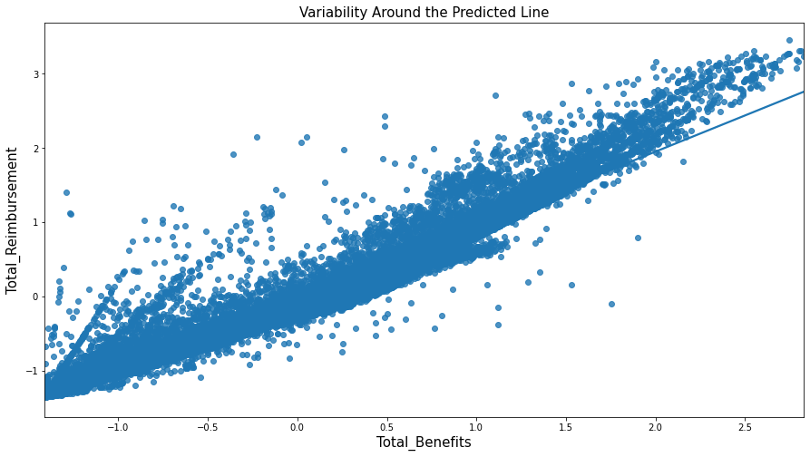

```python
# set the plot size using figure()
# pass width and height in inches to 'figsize'
plt.figure(figsize = (15,8))

# plot a regression plot
# independent variable on x-axis and dependent variable on y-axis
sns.regplot(x = X_train_slr['Total_Benefits'], y = y_train_slr)

# add axes and plot labels
# set text size using 'fontsize'
plt.title('Variability Around the Predicted Line', fontsize = 15)
plt.xlabel('Total_Benefits', fontsize = 15)
plt.ylabel('Total_Reimbursement', fontsize = 15)

# display the plot
plt.show()
```

**Interpretation:** The blue line in the plot, indicates the regression line for the data. We can observe that most of the data points lie on (or near) the line. Also, some of the points are away from the line, which concludes the variation of the data to the fitted line.

## 4.3 Inferences about Slope and Intercept

Let us print the summary of the regression model (built in section 4.1).

```python
# print the model summary
print(SLR_model.summary())
```

```
                             OLS Regression Results
===============================================================================
Dep. Variable:     Total_Reimbursement   R-squared:                       0.949
Model:                             OLS   Adj. R-squared:                  0.949
Method:                  Least Squares   F-statistic:                 4.848e+05
Date:                 Fri, 16 Oct 2020   Prob (F-statistic):               0.00
Time:                         15:58:58   Log-Likelihood:                 1661.7
No. Observations:                26320   AIC:                            -3319.
Df Residuals:                    26318   BIC:                            -3303.
Df Model:                            1
Covariance Type:             nonrobust
==================================================================================
                     coef    std err          t      P>|t|      [0.025      0.975]
----------------------------------------------------------------------------------
intercept       1.466e-05      0.001      0.010      0.992      -0.003       0.003
Total_Benefits     0.9744      0.001    696.263      0.000       0.972       0.977
==============================================================================
Omnibus:                    12064.055   Durbin-Watson:                   2.006
Prob(Omnibus):                  0.000   Jarque-Bera (JB):           117016.449
Skew:                           1.965   Prob(JB):                         0.00
Kurtosis:                      12.553   Cond. No.                         1.00
==============================================================================

Warnings:
[1] Standard Errors assume that the covariance matrix of the errors is correctly specified.
```

Now, let us make some inferences about the output given above.